# Logistic Regression

Danae Martinez

20/11/2020

## Logistic regression

Logistic regression is a special case of a broader class of generalized linear models, often known as GLMs. This model differs from other models of regression, due to the fact that the response variable is dichotomic. It produces result that are typically interpreted in one of two ways:

1. **Odds ratios**

Odds are the ratio of the probability that something happens to the probability it doesn’t happen.

$$\Omega(X_i) = \frac{P(y=1|X_i)}{1-P(y=1|X_i)}$$

Recall that in logistic regression

$$P(y=1|X_i) = \frac{\exp^{\beta X_i}}{1+\exp^{\beta X_i}}$$
which means that $\Omega(X_i)$ can be written

$$\Omega(X_i) = \exp(\hat\beta X_i)$$

An odds ratio is the ratio of two odds, each calculated at a different score for $X$.

$$OR = \frac{\Omega(X_i)}{\Omega(X_j)}$$
2. **Predicted probabilities**

Are intuitive, but require assuming a value for every covariate.

## Example of simple logistic regression

## Exploring the credit data

| loan_status | loan_amnt | grade | home_ownership | annual_inc | age | emp_cat | ir_cat |
| --- | --- | --- | --- | --- | --- | --- | --- |
| 0 | 5000 | B | RENT | 24000 | 33 | 0-15 | 8-11 |
| 0 | 2400 | C | RENT | 12252 | 31 | 15-30 | Missing |
| 0 | 10000 | C | RENT | 49200 | 24 | 0-15 | 11-13.5 |
| 0 | 5000 | A | RENT | 36000 | 39 | 0-15 | Missing |
| 0 | 3000 | E | RENT | 48000 | 24 | 0-15 | Missing |
| 0 | 12000 | B | OWN | 75000 | 28 | 0-15 | 11-13.5 |

```r
set.seed(567)

#create an ID
loan_data <- loan_data %>% mutate(id = row_number())

#Create training set
training_set <- loan_data %>% sample_frac(.70)

#Create test set
test_set <- anti_join(loan_data, training_set, by = 'id')
```

### Basic logistic regression

```r
# fit model
log_model <- glm(loan_status ~ age , family = binomial(link = "logit"), data = training_set)
summary(log_model)
```

```
##
## Call:
## glm(formula = loan_status ~ age, family = binomial(link = "logit"),
##     data = training_set)
##
## Deviance Residuals:
##     Min       1Q   Median       3Q      Max
## -0.4951  -0.4893  -0.4850  -0.4766   2.2089
##
## Coefficients:
##              Estimate Std. Error z value Pr(>|z|)
## (Intercept) -1.912748   0.104321 -18.335   <2e-16 ***
## age         -0.006223   0.003699  -1.682   0.0925 .
## ---
## Signif. codes:  0 '***' 0.001 '**' 0.01 '*' 0.05 '.' 0.1 ' ' 1
##
## (Dispersion parameter for binomial family taken to be 1)
##
##     Null deviance: 14163  on 20363  degrees of freedom
## Residual deviance: 14160  on 20362  degrees of freedom
## AIC: 14164
##
## Number of Fisher Scoring iterations: 4
```

| Variable | Estimate | Std. Error | z value | Pr(>\|z\|) |
| --- | --- | --- | --- | --- |
| (Intercept) | -1.913 | 0.104 | -18.335 | 0.000 |
| age | -0.006 | 0.004 | -1.682 | 0.092 |

### Interpretation of coefficient

Note that the mathematical model is now:

$$\log (\Omega(X_i)) = \hat\beta X_i + \epsilon$$
To interpret the coefficient in terms of the OR, let’s say

$$OR = \frac{\Omega(X_i=31)} {\Omega(X_i=30)} = \frac{\exp(-1.91-0.006*31)}{ \exp(-1.91-0.006*30)} = \exp(\beta_1)$$

```r
exp(estimates[1] + estimates[2]*31)/exp(estimates[1] +  estimates[2]*30)
```

```
## (Intercept)
##    0.994018
```

```r
exp(estimates[2])
```

```
##      age
## 0.994018
```

If variable age goes down by 1, the odds of getting a loan are 1.006018 bigger than the odds of not getting it. Similarly

$$OR = \frac{\Omega(X_i=35)} {\Omega(X_i=30)} = \frac{\exp(-1.91-0.006*35)}{ \exp(-1.91-0.006*30)} = \exp(5*\beta_1)$$

```r
exp(estimates[1] + estimates[2]*35)/exp(estimates[1] +  estimates[2]*30)
```

```
## (Intercept)
##   0.9704455
```

```r
exp(5*estimates[2])
```

```
##       age
## 0.9704455
```

If variable age down up by 5, the odds of getting a loan are 1.0304545 bigger than the odds of not getting it.

Remark: since $\beta_1 < 0$, then $\exp(\beta_1) < 1$ which implies that the odds of getting a loan decrease as the age increases

## Interpreting as predicted probabilities

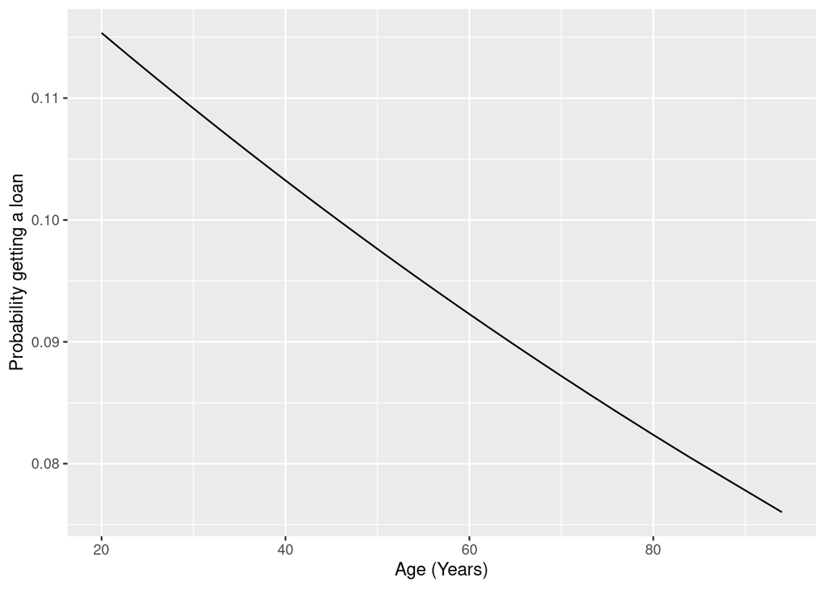